# R Bootcamp 2.3 Correlation

last updated: 2021-10-19

## Sampling and distributions

> Ice cream sales and forest fires are correlated because both occur more often in the summer heat. But, **correlation does not imply causation**.

-Nate Silver

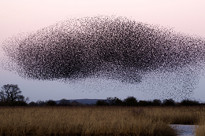

## What you will learn

- The question of correlation
- Data and assumptions
- Graphing
- Tests and alternatives
- Practice exercises

## The question of correlation

- Measure of **association**
- 2 (or more) **numeric variables**
- General correlation: a relationship
- Specific correlation: correlation coefficient

## The question of correlation

Graph a correlation with a scatterplot

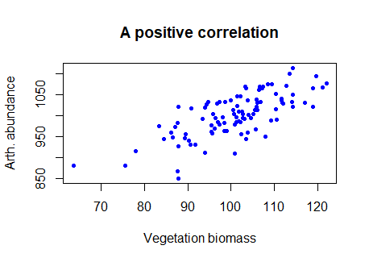

## The question of correlation

Given some data:

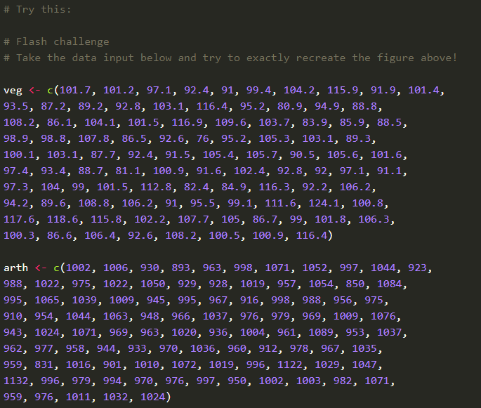

## The question of correlation

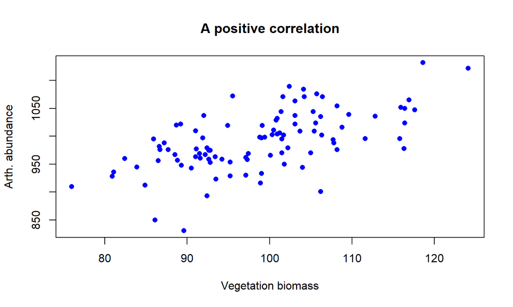

```r
plot(x = veg, y = arth,
     xlab = 'Vegetation biomass', ylab = 'Arth. abundance',
     main = 'A positive correlation',
     pch = 16, col = 'blue')
```

## Data and assumptions

The correlation coefficient is the **covariance** of 2 numeric variables divided by the product of their standard deviations

-1 < r < 1

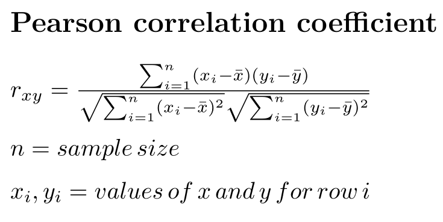

## Data and assumptions

The correlation coefficient is the **covariance** of 2 numeric variables

```r
# The 'hard' way
# (sample) covariance
cov_veg_arth <- sum( (veg-mean(veg))*(arth-mean(arth))) /
                      (length(veg) - 1 )

# r
(r_arth_veg <- cov_veg_arth / (sd(veg) * sd(arth)))
```

```
## [1] 0.6056694
```

## Data and assumptions

The correlation coefficient is the **covariance** of 2 numeric variables

Assumptions:

- linear relationship between variables
- Gaussian distribution for each variable

## Data and assumptions

The correlation coefficient is the **covariance** of 2 numeric variables

```r
# The 'easy' way
cor(veg, arth)
```

```
## [1] 0.6056694
```

## Graphing

A range of correlation magnitudes and signs

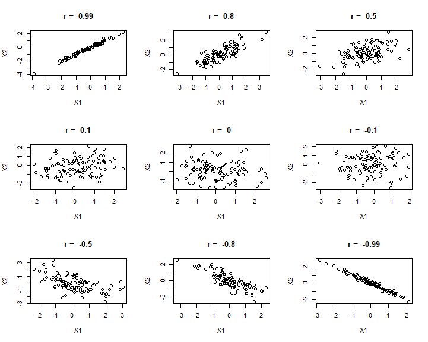

## Graphing

The `pairs()` function is useful for EDA

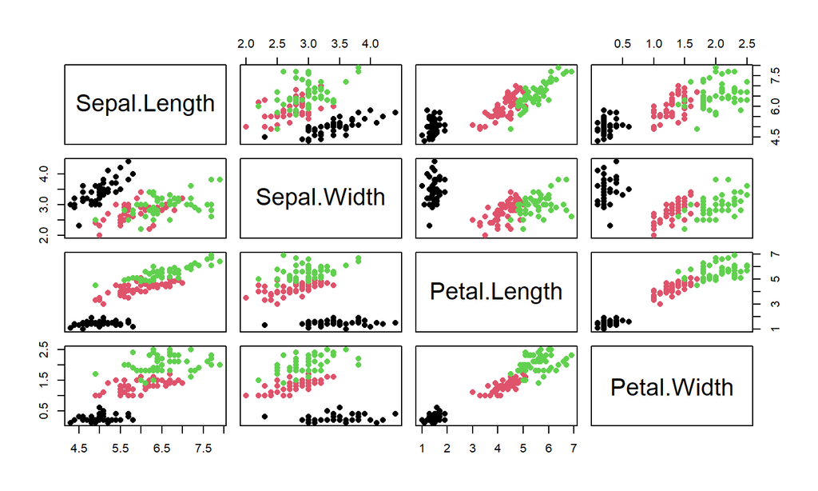

```r
data(iris)
# pairs plot
pairs(iris[ , 1:4], pch = 16,
      col = iris$Species) # Set color to species...
```

## Tests and alternatives

- Significance test (null: r == 0)
- **`cor.test()`** function
- **Pearson correlation** is traditional, with assumptions
- Alternative weaker test is the **Spearman Rank correlation** if assumptions are not met

## Tests and alternatives

```r
cor.test(veg, arth)
```

```
##
##  Pearson's product-moment correlation
##
## data:  veg and arth
## t = 7.4966, df = 97, p-value = 3.101e-11
## alternative hypothesis: true correlation is not equal to 0
## 95 percent confidence interval:
##  0.4637006 0.7173146
## sample estimates:
##       cor
## 0.6056694
```

## Tests and alternatives

Reporting results (NEVER PASTE RAW OUTPUT)

> We found a significant correlation between vegetation biomass and arthropod abundance (Pearson’s r = 0.61, df = 97, P < 0.0001)

## Live coding

[figure not shown]